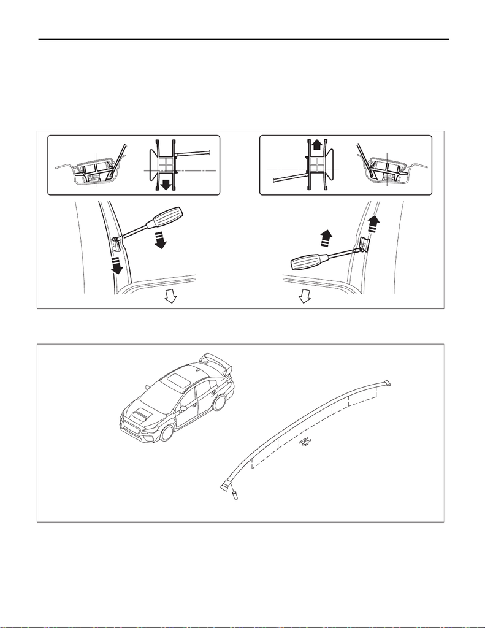

EI-48

Roof Molding

EXTERIOR/INTERIOR TRIM

11.Roof Molding

A: REMOVAL

CAUTION:

Be careful not to damage the body.

1) Turn over the front end of the molding - roof.

2) Slide the inner fastener in the direction of the arrow using a flat tip screwdriver, then remove the fastener

from the stud on the vehicle side.

Right side: Slide towards the front of the vehicle.

Left side: Slide towards the rear of the vehicle.

6 places per side

3) Pull up the molding - roof, and remove from the vehicle.

EI-04391

Front Front

EI-04336

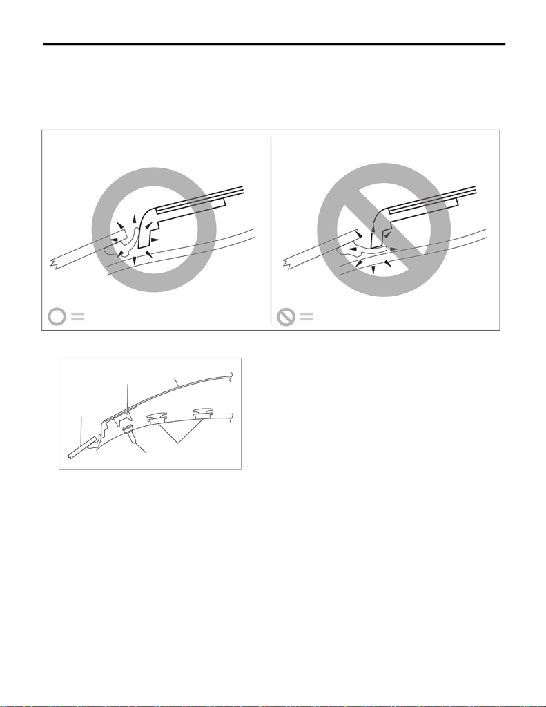

EI-49

Roof Molding

EXTERIOR/INTERIOR TRIM

B: INSTALLATION

1) Remove the clips from the molding - roof, and attach to the studs on the vehicle.

CAUTION:

• Always replace the clips that were damaged during removal of the molding - roof with new parts.

• While installing the molding - roof, be careful not to catch the glass molding with the tip of the front

side and rear side.

2) Push the front end of the molding - roof against the front window, and attach the forward positioning clip

onto the rivet on the body.

3) While pushing down the molding - roof from above, connect the molding - roof and the clip.

EI-02762

NG

=

OK

=

EI-02761

(2)

(1)

(4)

(5)

(3)

(1) Windshield

(2) Positioning clip

(3) Molding - roof

(4) Rivet

(5) Clip